# Unstructured Data Analytics

Lab 1

## Step 1 – Messing With APIs

Using APIs is an important part of modern data acquisition tasks. Fortunately, they are pretty easy to put together (so long as you can follow some instructions). We are going to be working with REST APIs, so we can essentially just pass a URL request to a server – the words make it sound more complicated than it actually is.

Let’s start by playing with the [Yelp Fusion API](https://www.yelp.com/developers/documentation/v3). If you were doing this on your own, you would need to register an app so that you could get a *token* (or *key*, or *secret*) – mine is given below if you don’t want to mess with getting your own. While I have provided mine for your temporary convenience, you should really mess with getting your own sooner rather than later. All you need to do is register for an account and create a new app.

You will see many services will ask you to create an app and it is never complicated. They really just want a name and sometimes and page (I direct them to the Mendoza page).

When creating these URLs, we are given a base url, usually something like `https://api.yelp.com/v3/` and then we start adding stuff to it. Most of the stuff that we would want from Yelp is on the *business* directory, so we can add that to the link – `https://api.yelp.com/v3/businesses/`. Next, we might want to do something very simple, like search for a restaurant. We will need to tell the API what we are doing – `https://api.yelp.com/v3/businesses/search`.

The API now knows that we will be utilizing the search service. If you have ever included some of the extra information on a Youtube link, the next part will look pretty familiar to you: `https://api.yelp.com/v3/businesses/search?term=cambodian+thai`. Right after our `search` parameter, we pass an argument called `term` and set it equal to our search query. You likely noticed that what should have been a space was replaced by a `+` – URLs do not do spaces and other special characters. While the `+` works just fine for a space, you might want to familiarize yourself with [URL encoding](https://www.w3schools.com/tags/ref_urlencode.asp). Finally, our search parameter needs another argument, `location`, giving us `https://api.yelp.com/v3/businesses/search?term=cambodian+thai&location=south+bend`.

That is the first, and most difficult, step in getting an API call ready. The next part is pretty easy – we just need to pass our authentication key into the request. Again, this is something that sounds tricky, but really is pretty easy.

Remember how we explored the headers within a request? These headers are where we will pass information along to the server. Most APIs only require a little bit of information to be passed into the header. This information takes the form of the authentication aspect of the request.

```r
library(httr)

library(jsonlite)

library(rvest)

apiKey = "8my5DQcAI1nxMW7oMTyZd-NIFHFQElynCZ35OWJSBMihg0YPJQfYxDUrK_2kx1qxdTWMneXwLOvYgkAbHpzIVXRsxXyLlnFA2gLACOBz9BsdCdowYo5rnZVp3khHXHYx"

thaiSearch = GET("https://api.yelp.com/v3/businesses/search?term=cambodian+thai&location=south+bend&limit=2",
                 add_headers(Authorization = paste("Bearer", apiKey, sep = " ")))
```

The `Authorization: Bearer key` construction is common.

## Step 2 – Parsing The Return

There will be times when working with an API is a one-step process, but…this is rarely the case. First, most API requests are going to come through in JSON. We will need to parse the request:

```r
searchParsed = jsonlite::fromJSON((content(thaiSearch, as = "text")))

searchParsed
```

```
$businesses
                      id                     alias           name
1 bx2rCVErnRJ2SBxe7tKy7w cambodian-thai-south-bend Cambodian Thai
2 y7cfW9joFCSwJnr9GQqpdg    nom-nom-pho-south-bend    Nom Nom Pho
                                                             image_url
1 https://s3-media1.fl.yelpcdn.com/bphoto/_RsBieBW7P1vVHcHkvs8PA/o.jpg
2 https://s3-media3.fl.yelpcdn.com/bphoto/1RLF3KitcYcbuhKaHkw3jA/o.jpg
  is_closed
1     FALSE
2     FALSE
                                                                                                                                                                                     url
1 https://www.yelp.com/biz/cambodian-thai-south-bend?adjust_creative=PzWF7Y9nlCzNa8EEVVDf_g&utm_campaign=yelp_api_v3&utm_medium=api_v3_business_search&utm_source=PzWF7Y9nlCzNa8EEVVDf_g
2    https://www.yelp.com/biz/nom-nom-pho-south-bend?adjust_creative=PzWF7Y9nlCzNa8EEVVDf_g&utm_campaign=yelp_api_v3&utm_medium=api_v3_business_search&utm_source=PzWF7Y9nlCzNa8EEVVDf_g
  review_count
1          313
2          129
                                                   categories rating
1 thai, cambodian, asianfusion, Thai, Cambodian, Asian Fusion      4
2                          vietnamese, thai, Vietnamese, Thai      4
  coordinates.latitude coordinates.longitude transactions price
1             41.67384             -86.25078     delivery     $
2             41.67820             -86.25222                 $$
  location.address1 location.address2 location.address3 location.city
1 235 S Michigan St                                        South Bend
2     213 N Main St                                <NA>    South Bend
  location.zip_code location.country location.state
1             46601               US             IN
2             46601               US             IN
                 location.display_address        phone  display_phone
1 235 S Michigan St, South Bend, IN 46601 +15742892877 (574) 289-2877
2     213 N Main St, South Bend, IN 46601 +15744046480 (574) 404-6480
  distance
1 1530.126
2 1382.546

$total
[1] 12

$region
$region$center
$region$center$longitude
[1] -86.26877

$region$center$latitude
[1] 41.67683
```

There are many different ways of parsing this request (e.g., `content(thaiSearch, as = "parsed")`), but the above will work pretty well for our current case.

In looking at our `searchParsed` object, we should have a pretty good idea about what we want:

```r
thaiResults = searchParsed$businesses[1, ]
```

## Step 3 – Passing Information

In many API scenarios, you will be looking at a few steps to get to where you want to be. If we want to have more information about Cambodian Thai, we can get the information directly once we have the ID (which we got from our search).

```r
thaiID = paste("https://api.yelp.com/v3/businesses/", thaiResults$id, sep = "")

cambodianThai = GET(thaiID,
    add_headers(Authorization = paste("Bearer", apiKey, sep = " ")))

thaiParsed = jsonlite::fromJSON(content(cambodianThai, as = "text"))
```

On occasion, you might need to do some silly stuff to work that json stuff into a reasonable data frame:

```r
content(cambodianThai, as = "text") %>%
  jsonlite::fromJSON(., simplifyDataFrame = TRUE, flatten = TRUE) %>%
  unlist() %>%
  t() %>%
  tibble::as_tibble()
```

```
# A tibble: 1 x 60
  id    alias name  image_url is_claimed is_closed url   phone
  <chr> <chr> <chr> <chr>     <chr>      <chr>     <chr> <chr>
1 bx2r… camb… Camb… https://… FALSE      FALSE     http… +157…
# … with 52 more variables: display_phone <chr>, review_count <chr>,
#   categories.alias1 <chr>, categories.alias2 <chr>,
#   categories.alias3 <chr>, categories.title1 <chr>,
#   categories.title2 <chr>, categories.title3 <chr>, rating <chr>,
#   location.address1 <chr>, location.address2 <chr>,
#   location.address3 <chr>, location.city <chr>,
#   location.zip_code <chr>, location.country <chr>,
#   location.state <chr>, location.display_address1 <chr>,
#   location.display_address2 <chr>, location.cross_streets <chr>,
#   coordinates.latitude <chr>, coordinates.longitude <chr>,
#   photos1 <chr>, photos2 <chr>, photos3 <chr>, price <chr>,
#   hours.open.is_overnight1 <chr>, hours.open.is_overnight2 <chr>,
#   hours.open.is_overnight3 <chr>, hours.open.is_overnight4 <chr>,
#   hours.open.is_overnight5 <chr>, hours.open.is_overnight6 <chr>,
#   hours.open.start1 <chr>, hours.open.start2 <chr>,
#   hours.open.start3 <chr>, hours.open.start4 <chr>,
#   hours.open.start5 <chr>, hours.open.start6 <chr>,
#   hours.open.end1 <chr>, hours.open.end2 <chr>,
#   hours.open.end3 <chr>, hours.open.end4 <chr>,
#   hours.open.end5 <chr>, hours.open.end6 <chr>,
#   hours.open.day1 <chr>, hours.open.day2 <chr>,
#   hours.open.day3 <chr>, hours.open.day4 <chr>,
#   hours.open.day5 <chr>, hours.open.day6 <chr>,
#   hours.hours_type <chr>, hours.is_open_now <chr>,
#   transactions <chr>
```

## Step 4 – Scraping Some Text

Now we want to scrape some text about Cambodian Thai. We can do this in the standard way with our `rvest` code.

### IMPORTANT NOTE

The following code for `ctRatings` will not likely work. While the order of the selectors is correct, the characters (e.g., Y2F3O) seem to change almost daily. You might also find that it returns 21 star ratings instead of 20 ratings – it is very likely to be the overall rating and can be dropped after you explore it.

```r
library(rvest)

cambodianThai = "https://www.yelp.com/biz/cambodian-thai-south-bend"

cambodianThaiHTML = read_html(cambodianThai)

ctRatings = cambodianThaiHTML %>%
  html_nodes(".lemon--div__373c0__1mboc.arrange__373c0__UHqhV.gutter-6__373c0__zqA5A.vertical-align-middle__373c0__2TQsQ.border-color--default__373c0__2oFDT .lemon--div__373c0__1mboc.arrange-unit__373c0__1piwO.border-color--default__373c0__2oFDT .lemon--span__373c0__3997G.display--inline__373c0__2q4au.border-color--default__373c0__YEvMS .lemon--div__373c0__1mboc.i-stars__373c0__Y2F3O") %>%
  html_attr("aria-label") %>%
  stringr::str_extract("[0-5]")

ctRatings = ctRatings[-c(1)]

ctReviews = cambodianThaiHTML %>%
  html_nodes("p.lemon--p__373c0__3Qnnj.text__373c0__2pB8f.comment__373c0__3EKjH.text-color--normal__373c0__K_MKN.text-align--left__373c0__2pnx_ .lemon--span__373c0__3997G") %>%
  html_text()

ctData = data.frame(ratings = ctRatings,
                    reviews = ctReviews,
                    restaurant = "cambodian thai",
                    stringsAsFactors = FALSE)

DT::datatable(ctData)
```

|  | ratings | reviews | restaurant |
| --- | --- | --- | --- |
| 1 | 4 | We ate here while visiting our daughter at school. The food is really good and the portions are a good size. We enjoyed the wonton soup and drunken noodles. Service was good and friendly. Only giving … | cambodian thai |
| 2 | 2 | I'm not sure why the average rating here is so high, but I thought the food here was very average and overly sweet. It's possible that it's the best option for Thai food in the area but objectively it… | cambodian thai |
| 3 | 2 | I decided to try Cambodian Thai based on a friend's recommendation. The restaurant is located on the south end of South Michigan Street in downtown South Bend, on the same block as the old Dainty Maid… | cambodian thai |
| 4 | 5 | It has only been two weeks since I was first introduced to this local gem by an associate of mine, and already, I have visited three times just to thrill my tongue with the spices, the flavors, the fr… | cambodian thai |
| 5 | 5 | Really good thai food for the area! I think their special dish is the pad thai because they can make it crispy (this is definitely a must try!). Be aware that their food gets really spicy so for me at… | cambodian thai |
| 6 | 3 | The food was excellent but there is not enough staff. We had to wait for for extra items such as sauces, refills and such. The staff was very friendly. The place was packed so you know they are doing … | cambodian thai |
| 7 | 5 | Dankest Thai you'll find in a 50 mile radius. Hands down one of my favorite establishments in all of south bend for food. Do be weary of heat levels. I've asked for 5/10-7/10 and one time 8. The step … | cambodian thai |
| 8 | 4 | It's been quite a while since I've eaten at a Thai restaurant and I though I'd give Thai food another try, since my last experience was memorable. What sparked my interest is Cambodian Thai unlike oth… | cambodian thai |
| 9 | 4 | Very attentive staff.Food extremely good value for portions.Clean dining area.Quality is great.I had the drunken noodles and family had the Pad Thai.Only drawback was parking. | cambodian thai |
| 10 | 3 | Not sure how this place gets such high ratings maybe I came on a bad day. The prices are affordable the staff is pretty nice and attentive. the food looks good however I'm sure they served me at least… | cambodian thai |

[output cut: 10 more lines]

You might also be wondering why it took so much effort to get those star ratings. If we just grab the most simple selectors (i.e., the last chunk of selectors), we will grab a bunch of stuff that we don’t need.

### An Aside

I have mentioned that websites will change and they are not concerned with telling you about it. This is how the same code looked just a year ago:

```r
ctRatings = cambodianThaiHTML %>%
  html_nodes(".ratings-stars .i-stars") %>%
  html_attr("aria-label") %>%
  stringr::str_extract("[0-5]")

ctReviews = cambodianThaiHTML %>%
  html_nodes(".ratings-reviews") %>%
  html_text()
```

Definitely an easier scrape!

## Step 4b

You should notice that we only pulled in 20 reviews, while we know that we have around 313 reviews (I have no doubt that you saw that in the parsed data). If we want them all, we need to do just a little more work. Since there are 20 reviews per page, we are looking at 16 pages worth of reviews. And since we know how the links are constructed, we can just create them:

```r
linkNumbers = seq(from = 0, to = (floor(thaiParsed$review_count / 20) * 20), by = 20)

links = paste("https://www.yelp.com/biz/cambodian-thai-south-bend?start=",
              linkNumbers, sep = "")

allReviews = lapply(links, function(x) {
  cambodianThai = x

  cambodianThaiHTML = read_html(cambodianThai)

  ctRatings = cambodianThaiHTML %>%
  html_nodes(".lemon--div__373c0__1mboc.arrange-unit__373c0__1piwO.arrange-unit-fill__373c0__17z0h.border-color--default__373c0__2oFDT .lemon--span__373c0__3997G.display--inline__373c0__1DbOG.border-color--default__373c0__2oFDT .lemon--div__373c0__1mboc.i-stars__373c0__Y2F3O") %>%
  html_attr("aria-label") %>%
  stringr::str_extract("[0-5]")

  ctReviews = cambodianThaiHTML %>%
    html_nodes("p.lemon--p__373c0__3Qnnj.text__373c0__2pB8f.comment__373c0__3EKjH.text-color--normal__373c0__K_MKN.text-align--left__373c0__2pnx_ .lemon--span__373c0__3997G") %>%
    html_text()

  ctData = data.frame(ratings = ctRatings,
                      reviews = ctReviews,
                      restaurant = "cambodian thai",
                      stringsAsFactors = FALSE)

  return(ctData)
})

allReviews = data.table::rbindlist(allReviews)
```

## Step 5 – Analyze The Text

Given what we have already seen, try to learn a little bit about what words are being used in the reviews. Can you pick out a dish that people seem to talk about frequently?

Just as a starting place, this might start to get at the dishes that are discussed:

```r
library(dplyr)

library(tidytext)

bigrams = ctData %>%
  unnest_tokens(., ngrams, reviews, token = "ngrams", n = 2) %>%
  tidyr::separate(ngrams, c("word1", "word2"), sep = "\\s") %>%
  count(word1, word2, sort = TRUE)

rmarkdown::paged_table(bigrams)
```

| word1 | word2 | n |
| --- | --- | --- |
| the | food | 18 |
| and | the | 13 |
| thai | food | 10 |
| of | the | 9 |
| in | the | 8 |
| it | was | 8 |
| on | the | 8 |
| of | my | 7 |
| fried | rice | 6 |
| i | was | 6 |

[output cut: 2331 more lines]

You might also want to find and grab the date for each review. This might make for some interesting plotting.

You can also produce some handy visualizations for your text:

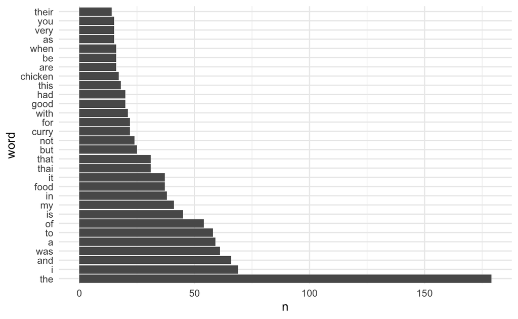

```r
library(ggplot2)

ctData %>%
  unnest_tokens(., word, reviews) %>%
  count(word, sort = TRUE) %>%
  slice(1:30) %>%
  mutate(word = factor(word, levels = unique(word))) %>%
  ggplot(., aes(word, n)) +
  geom_col() +
  coord_flip() +
  theme_minimal()
```

Can you remove the stopwords? If you create a data frame with multiple restaurants, can you reproduce that plot with multiple restaurants? Do any text features influence ratings? These are just a few of the things that you might want to explore.

# Your Deliverable

No matter how much work you get done, your goal is to produce a “three slide story”. There should be a problem statement, what you found, and what that means for solving the problem. You can have visualizations, but no code needs to be printed within the slides.